# Exploratory Analysis

## **Exploratory Data Analysis of the US Census**

## **Putting extracted information into pandas for data exploration and manipulation**

```python
# Librarys I'm going to be using
import numpy as np
import pandas as pd
import seaborn as sns
import matplotlib.pyplot as plt

# Extracting content from csv into pandas
extractedData = pd.read_csv('extractedData.csv')

# Dropping unneeded id column
extractedData = extractedData.drop('id', axis = 1)
extractedData.describe()
```

|  | age | education_num | capital_gain | capital_loss | hours_week | over_50k |
| --- | --- | --- | --- | --- | --- | --- |
| count | 48842.000000 | 48842.000000 | 48842.000000 | 48842.000000 | 48842.000000 | 48842.000000 |
| mean | 38.643585 | 10.078089 | 1079.067626 | 87.502314 | 40.422382 | 0.239282 |
| std | 13.710510 | 2.570973 | 7452.019058 | 403.004552 | 12.391444 | 0.426649 |
| min | 17.000000 | 1.000000 | 0.000000 | 0.000000 | 1.000000 | 0.000000 |
| 25% | 28.000000 | 9.000000 | 0.000000 | 0.000000 | 40.000000 | 0.000000 |
| 50% | 37.000000 | 10.000000 | 0.000000 | 0.000000 | 40.000000 | 0.000000 |
| 75% | 48.000000 | 12.000000 | 0.000000 | 0.000000 | 45.000000 | 0.000000 |
| max | 90.000000 | 16.000000 | 99999.000000 | 4356.000000 | 99.000000 | 1.000000 |

## **Visualizing the numerical features of the dataset**

### **From this we can observe a few things:**

- Most of the data is based on indivduals under 50
- The minority of people have captial gains or losses
- The most common amount of work per week is 40 hours, but the outliers lean more to 40+ hours

key:

- sexes: 0 = Female, 1 = Male
- over_50k: 0 = under 50 k, 1 = over 50 k

```
array([[<matplotlib.axes._subplots.AxesSubplot object at 0x7faa03ab5750>,
      dtype=object)
```

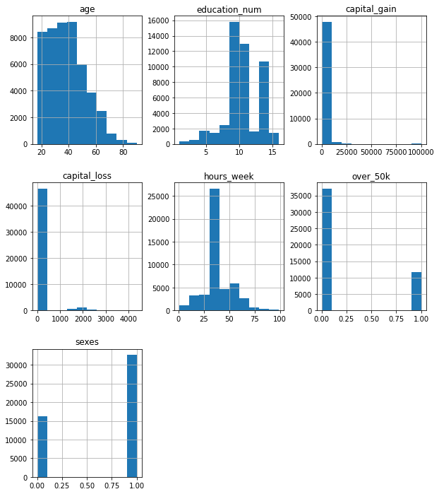

```python
# Selecting all the columns that contain numerical data
# Changing sexes to numerical to extract correlations, 1 Beging male and 0 being female
extractedData['sexes'] = extractedData['sexes'].replace({"Male":1, "Female": 0})
numerical_attributes = extractedData.select_dtypes(include = ['int'])

#Plots the numerical data
numerical_attributes.hist(figsize = (10,12))
```

#### Correlation Map of Numerical features

What does this tell us? We know that the following pairs have high correlations with earning over 50k a year:

- Age
- Education
- Sex
- Captial gain
- Hours worked per week

High correlations in regards to sex:

- Earning over 50k
- Hours worked a week

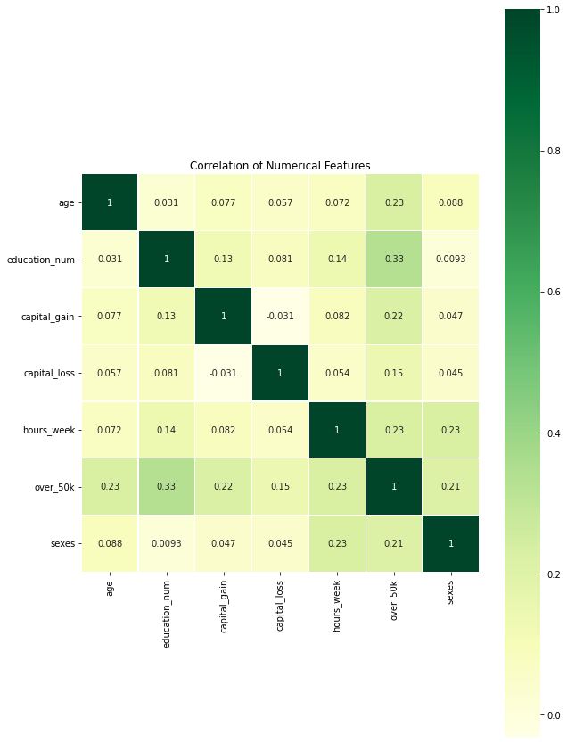

```python
# Getting correlations from dataframe
corr = numerical_attributes.corr()

# plotting the correlations
f, ax = plt.subplots(figsize = (10,15))
cmap = sns.diverging_palette(220, 10, as_cmap = True)
_ = sns.heatmap(corr, cmap = "YlGn", square = True, ax = ax , annot = True, linewidth = 0.1)

plt.title('Correlation of Numerical Features')
```

## **Visualizing all the categorical features of the dataset**

#### Work Classes

Noticeable infomration: the most popular work class based on the data is private. The other people who aren't in private are pretty much equaly spread out through the goverment jobs and not many people don't work or go without pay.

```
[Text(0.5, 1.0, 'Work Classes')]
```

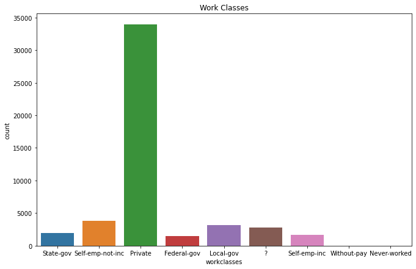

```python
# Selecting the catagorical features
extractedData['sexes'] = extractedData['sexes'].replace({1:"Male", 0:"Female"})
extractedData['over_50k'] = extractedData['over_50k'].replace({0:"Under 50k", 1: "Over 50k"})

# Making age into catagorical data type
catagory = pd.cut(extractedData.age,bins=[17,20,30,40,50,65,99] ,labels=['[17-20]', '[20-30]', '[30,40]', '[40-50]', '[50-65]', '[60+]'])
extractedData.insert(0, "age_group", catagory)


catagorical_attributes = extractedData.select_dtypes(include = ['object'])

# Plotting the diffrent employments
plt.figure(figsize = (11,7))
sns.countplot(data = catagorical_attributes, x = "workclasses").set(title='Work Classes')
```

#### Occupations

```
[Text(0.5, 1.0, 'Occupations')]
```

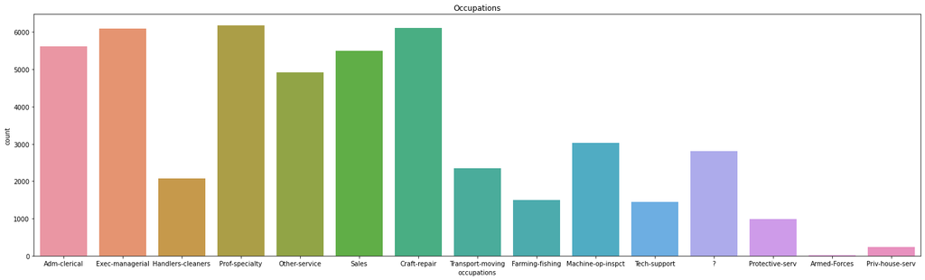

```python
plt.figure(figsize = (25,7))
sns.countplot(data = catagorical_attributes, x = "occupations").set(title='Occupations')
```

#### **Education**

- Most people are at least a highschool graduate and/or have attended college.

```
[Text(0.5, 1.0, 'Education')]
```

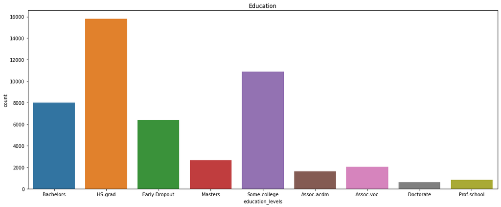

```python
# Plotting the Education of all individuals
plt.figure(figsize = (18,7))

# Renaming some education levels for less cluttered graphs
catagorical_attributes['education_levels'].replace('Preschool', 'Early Dropout', inplace = True)
catagorical_attributes['education_levels'].replace('1st-4th', 'Early Dropout', inplace = True)
catagorical_attributes['education_levels'].replace('5th-6th', 'Early Dropout', inplace = True)
catagorical_attributes['education_levels'].replace('7th-8th', 'Early Dropout', inplace = True)
catagorical_attributes['education_levels'].replace('9th', 'Early Dropout', inplace = True)
catagorical_attributes['education_levels'].replace('10th', 'Early Dropout', inplace = True)
catagorical_attributes['education_levels'].replace('11th', 'Early Dropout', inplace = True)
catagorical_attributes['education_levels'].replace('12th', 'Early Dropout', inplace = True)



sns.countplot(data = catagorical_attributes, x = "education_levels").set(title='Education')
```

#### Over 50k

Based of the data there is noticeably more people who make under 50 k than over.

```
[Text(0.5, 1.0, 'Over 50k')]
```

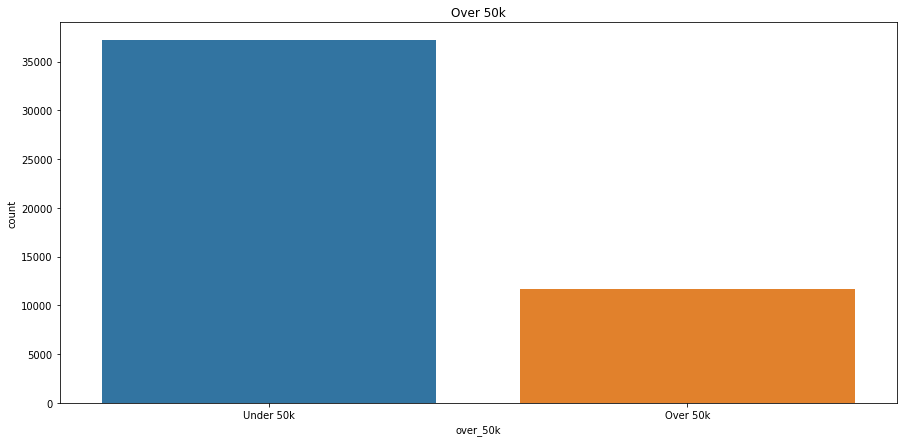

```python
plt.figure(figsize = (15,7))
sns.countplot(data = catagorical_attributes, x = "over_50k").set(title='Over 50k')
```

## **Income and Work Analysis**

Here I'll be looking at cross table graphs to try and visulize some of the correlations mentioned earlier, to see if there is any meaningful trends.

#### Occupation vs Income

Here we can observe that the two occupations with the highest pay are either professional specialties and executive mangerial workers. This most likely correlates with the education and experience required to be in either position.

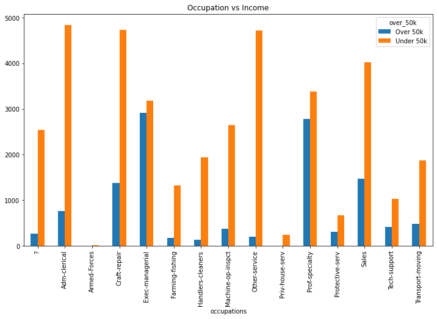

```python
crossTable = pd.crosstab(catagorical_attributes['occupations'], catagorical_attributes['over_50k']).plot.bar(stacked = False, figsize = (12,7)).set(title = "Occupation vs Income")
```

#### Education vs Income

Now looking at education aginst income it further proves that more pay comes with education. We can see here that as education is higher the proportion of under 50k to over 50k begins to lean more towards more people earning over 50k.

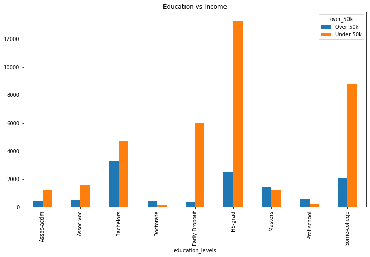

```python
crossTable = pd.crosstab(catagorical_attributes['education_levels'], catagorical_attributes['over_50k']).plot.bar(stacked = False, figsize = (12,7)).set(title = "Education vs Income")
```

#### Age vs Income

Here we can also observe that when it comes to younger people and older people there is a less likelyhood of making over 50k per year. This is probably due to either low experience or retiring. So the age group that earns the most seems to come from the 40 to 50 year olds. Which makes sense since they are usually the most experienced.

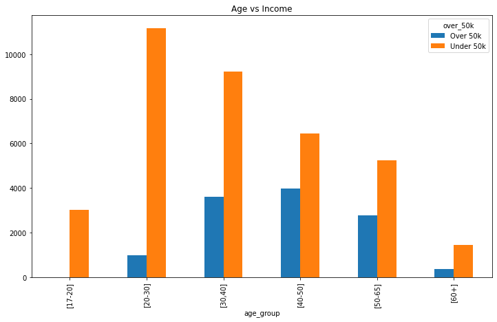

```python
crossTable = pd.crosstab(extractedData['age_group'], catagorical_attributes['over_50k']).plot.bar(stacked = False, figsize = (12,7)).set(title = "Age vs Income")
```

#### Sex vs Income

It's noticable from this data that males tend to earn over 50k more than females. This could be due to lower work hours leading to lower income per year.

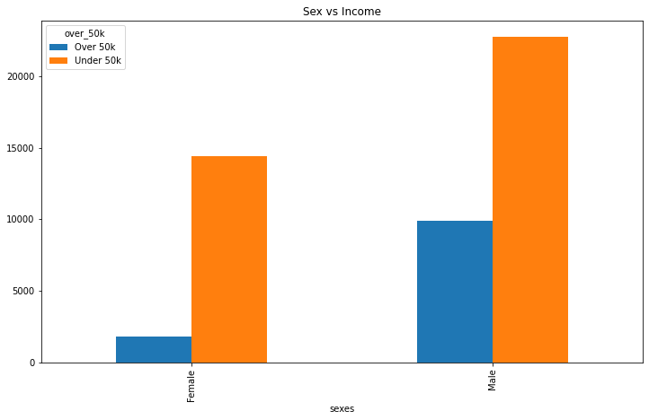

```python
crossTable = pd.crosstab(catagorical_attributes['sexes'], catagorical_attributes['over_50k']).plot.bar(stacked = False, figsize = (12,7)).set(title = "Sex vs Income")
```

#### Hour worked per week vs Income

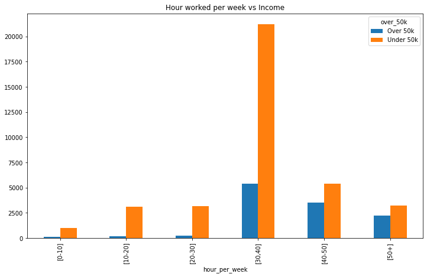

```python
# Putting hours worked per week into catagorical bins
catagory = pd.cut(extractedData.hours_week,bins=[0,10,20,30,40,50, 99] ,labels=['[0-10]', '[10-20]', '[20-30]', '[30,40]', '[40-50]', '[50+]'])
extractedData.insert(0, "hour_per_week", catagory)

crossTable = pd.crosstab(extractedData['hour_per_week'], catagorical_attributes['over_50k']).plot.bar(stacked = False, figsize = (12,7)).set(title = "Hour worked per week vs Income")
```

#### Hours worked per week vs Sex

From the data gathered from the graph we can see that the lower hours worked per week has more women and the higher hours go to men.

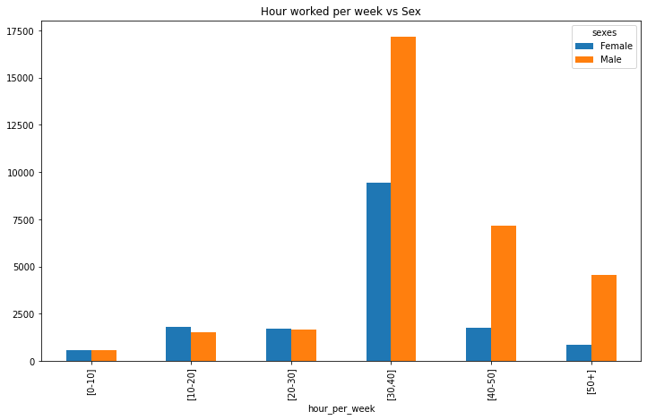

```python
crossTable = pd.crosstab(extractedData['hour_per_week'], catagorical_attributes['sexes']).plot.bar(stacked = False, figsize = (12,7)).set(title = "Hour worked per week vs Sex")
```

## **Summary**

From data exploration there is quite a bit of conclusions that we would be able to draw about the population in this time period.

- We were able to see that with age, experience/education, and hours worked per week, all correlated to making an income over 50k per year. Although it seems like the most influencial factor is edcucation.
- We were also able to see possibly why men had a higher proportion of making over 50k than women. With the most influenctial factor seeming to be that more men worked more hours a week than women.